# 第一次作业你的报告题目

发现：

- 发现1

  总体来看，房屋面积越大，总价越高

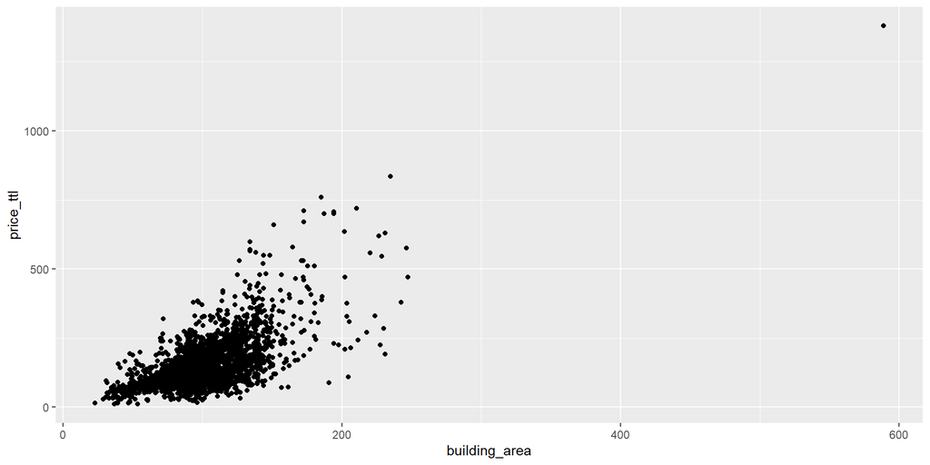

- 发现2

  180平米以上的房屋，面积越大总价越高的趋势不明显或者无此趋势。

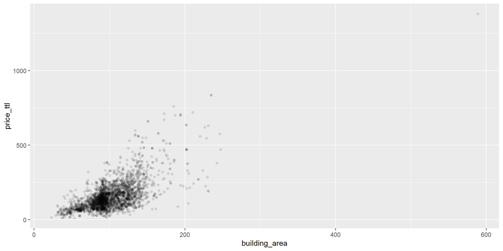

## 4.4 探索问题1

发现：

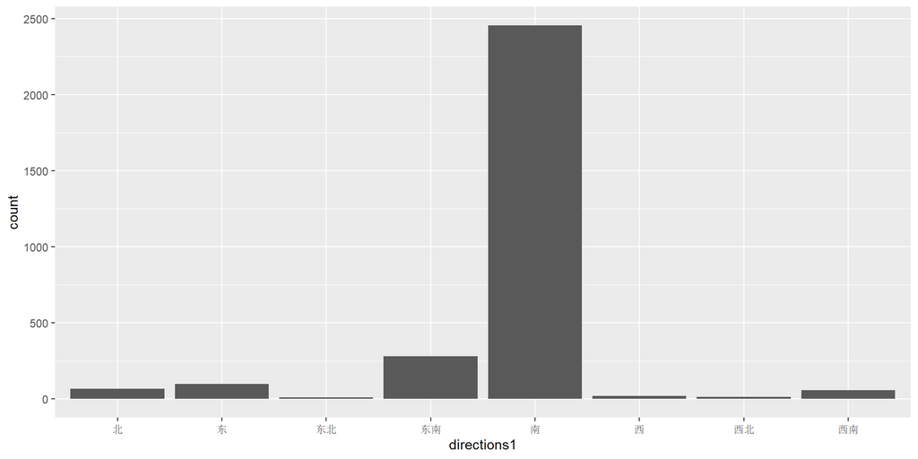

- 发现1

朝南的房子占大多数。还有可能是大家都觉得朝南的房子好，填写的时候都写朝南。

- 发现2

  朝向为东北，西北，西的房子最少。

## 4.5 探索问题2

发现：

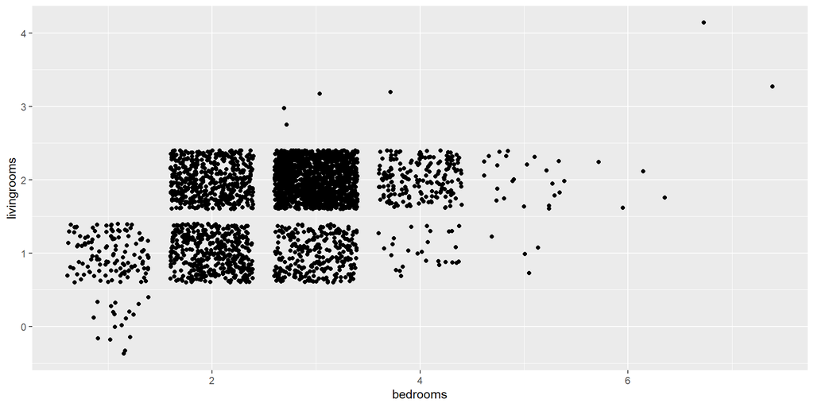

- 发现1

  三室两厅的房屋数量最多。
- 发现2

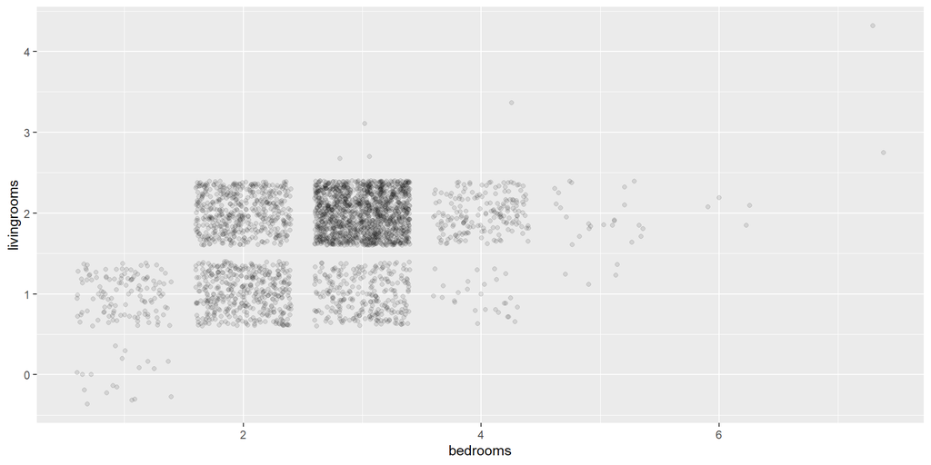

## 4.6 探索问题3

发现：

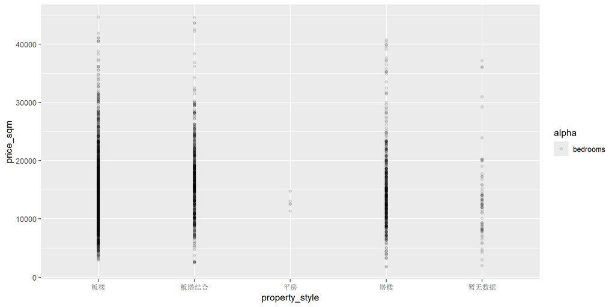

- 发现1 板楼的数量最多
- 发现2 塔楼的单价上限较板楼和板塔结合的房屋低 —

# 5 发现总结